# CMSC320_Final_Project

Predicting Who Makes The NFL Postseason

Data Science Lifecycle Tutorial by Isaiah Chapman

Introduction

The National Football League is the most watched sports league in the United States of America. The league consists of 32 teams across the country. Each team plays 17 games every season, but before the 2021 season, every team played 16 games. The goal of each team is to win as many games as possible, make it to the postseason, and win the Super Bowl.

Below are the libraries needed for this tutorial. You will need to download them to follow the tutorial.

```python
# Standard Python libraries for data science
import numpy as np
import pandas as pd

# Python library for analysis of binary classification
import sklearn
from sklearn.metrics import roc_curve, auc
from sklearn.metrics import accuracy_score, classification_report, confusion_matrix

# Python library for graphing and visualizations
import matplotlib.pyplot as plt
```

Data Collection

Data collection is the first stage in the data science lifecycle. Some main ways that data is obtained in data science are through API calls, through databases or the data can be given to you.

Application Programming Interface or APIs are rules and protocols that allow a user to communicate with a server. However, for this tutorial, you can download the CSV file from https://www.kaggle.com/datasets/nickcantalupa/nfl-team-data-2003-2023?resource=download. Kaggle is a website where you can find many data sets and data science projects.

If you would like to know more about API and what an API is you can visit https://aws.amazon.com/what-is/api/.

We must first read the csv into a pandas dataframe. A data frame is one of the most common data structures use in data science.

```python
df = pd.read_csv('nfl_team_stats_2002-2023.csv')
```

Data Processing

The next step in the data science lifecycle is data processing. When you have obtained your data there may be missing values, unnecessary columns for your task, columns may need to be combined or separated, and many other things. It is extremely important for you to have your data in the correct format before you move on to any other part of the data science lifecycle.

```python
df.columns
```

```
Index(['season', 'week', 'date', 'away', 'home', 'score_away', 'score_home',
       'first_downs_away', 'first_downs_home', 'third_down_comp_away',
       'third_down_att_away', 'third_down_comp_home', 'third_down_att_home',
       'fourth_down_comp_away', 'fourth_down_att_away',
       'fourth_down_comp_home', 'fourth_down_att_home', 'plays_away',
       'plays_home', 'drives_away', 'drives_home', 'yards_away', 'yards_home',
       'pass_comp_away', 'pass_att_away', 'pass_yards_away', 'pass_comp_home',
       'pass_att_home', 'pass_yards_home', 'sacks_num_away',
       'sacks_yards_away', 'sacks_num_home', 'sacks_yards_home',
       'rush_att_away', 'rush_yards_away', 'rush_att_home', 'rush_yards_home',
       'pen_num_away', 'pen_yards_away', 'pen_num_home', 'pen_yards_home',
       'redzone_comp_away', 'redzone_att_away', 'redzone_comp_home',
       'redzone_att_home', 'fumbles_away', 'fumbles_home',
       'interceptions_away', 'interceptions_home', 'def_st_td_away',
       'def_st_td_home', 'possession_away', 'possession_home'],
      dtype='object')
```

```python
columnsToDelete = ['plays_away','plays_home', 'drives_away', 'drives_home',
                  'def_st_td_away', 'def_st_td_home', 'possession_away', 'possession_home',
                  'rush_att_away', 'rush_att_home', 'sacks_yards_away', 'sacks_yards_home',
                  'yards_away', 'yards_home', 'pen_num_away', 'pen_num_home',
                  'pass_comp_away', 'pass_att_away', 'pass_comp_home', 'pass_att_home',
                  'redzone_comp_away', 'redzone_att_away', 'redzone_comp_home',
                  'redzone_att_home', 'first_downs_away', 'first_downs_home', 'third_down_comp_away',
                  'third_down_att_away', 'third_down_comp_home', 'third_down_att_home',
                  'fourth_down_comp_away', 'fourth_down_att_away',
                  'fourth_down_comp_home', 'fourth_down_att_home' ]
df.drop(columns= columnsToDelete, inplace = True)
```

.info() can be used to see all the columns in your data with their types. It can also show if there are null values in a certain column. If a columns has a different number of non-null count than the rest of the columns that means they are nulls.

```python
df.info()
```

```
<class 'pandas.core.frame.DataFrame'>
RangeIndex: 5929 entries, 0 to 5928
Data columns (total 19 columns):
 #   Column              Non-Null Count  Dtype
---  ------              --------------  -----
 0   season              5929 non-null   int64
 1   week                5929 non-null   object
 2   date                5929 non-null   object
 3   away                5929 non-null   object
 4   home                5929 non-null   object
 5   score_away          5929 non-null   int64
 6   score_home          5929 non-null   int64
 7   pass_yards_away     5929 non-null   int64
 8   pass_yards_home     5929 non-null   int64
 9   sacks_num_away      5929 non-null   int64
 10  sacks_num_home      5929 non-null   int64
 11  rush_yards_away     5929 non-null   int64
 12  rush_yards_home     5929 non-null   int64
 13  pen_yards_away      5929 non-null   int64
 14  pen_yards_home      5929 non-null   int64
 15  fumbles_away        5929 non-null   int64
 16  fumbles_home        5929 non-null   int64
 17  interceptions_away  5929 non-null   int64
 18  interceptions_home  5929 non-null   int64
dtypes: int64(15), object(4)
memory usage: 880.2+ KB
```

Another part of data processing is filtering your data. This can be useful when you are only trying to look at data from a specific time period, location, or any other attribute. It is also important to remove as much useless data from your project at the beginning of the process because it will allow your code to run faster and with fewer computations throughout the process.

We will filter the data so only the last ten years will be present in the daat.

```python
temp_df = df[df['date'] > '2014-05-01']
temp_df.head()
```

|  | season | week | date | away | home | score_away | score_home | pass_yards_away | pass_yards_home | sacks_num_away | sacks_num_home | rush_yards_away | rush_yards_home | pen_yards_away | pen_yards_home | fumbles_away | fumbles_home | interceptions_away | interceptions_home |
| --- | --- | --- | --- | --- | --- | --- | --- | --- | --- | --- | --- | --- | --- | --- | --- | --- | --- | --- | --- |
| 3204 | 2014 | 1 | 2014-09-04 | Packers | Seahawks | 16 | 36 | 175 | 191 | 3 | 1 | 80 | 207 | 65 | 69 | 0 | 1 | 1 | 0 |
| 3205 | 2014 | 1 | 2014-09-07 | Saints | Falcons | 34 | 37 | 333 | 445 | 0 | 1 | 139 | 123 | 27 | 96 | 1 | 1 | 1 | 0 |
| 3206 | 2014 | 1 | 2014-09-07 | Bills | Bears | 23 | 20 | 167 | 341 | 1 | 2 | 193 | 86 | 108 | 43 | 0 | 1 | 1 | 2 |
| 3207 | 2014 | 1 | 2014-09-07 | Titans | Chiefs | 26 | 10 | 243 | 178 | 4 | 4 | 162 | 67 | 110 | 25 | 0 | 0 | 0 | 3 |
| 3208 | 2014 | 1 | 2014-09-07 | Vikings | Rams | 34 | 6 | 170 | 246 | 0 | 5 | 185 | 72 | 60 | 121 | 0 | 0 | 0 | 2 |

Next, we will separate the home team stats from the away team stats and change the columns' names to make them more consistent. We will also make a win column that shows whether a team won a game that week. We will denote a win with a 1 and a loss or tie with a 0. After away and home data will be combined into a new data frame.

```python
result_df = pd.DataFrame()

for index, row in temp_df.iterrows():
    # Create two new rows with alternating values from the original row
    away = {}
    home = {}

    # Looping through each columns
    for i, col in enumerate(temp_df.columns):
        # The first three rows should be the same for both the away and home team
        if i < 3:
            away[col] = row[col]
            home[col] = row[col]
        # If the column name end is away it is a stat for the away team else home team
        elif col.endswith('away'):
            away[col[:-5]] = row[col]
        else:
            home[col[:-5]] = row[col]

    # Changing column to team_name
    away['team_name'] = away.pop('')
    home['team_name'] = home.pop('')

    # Finding the winner for the game and giving that team one win
    if away['score'] > home['score']:
        away['wins'] = 1
        home['wins'] = 0
    elif away['score'] < home['score']:
        away['wins'] = 0
        home['wins'] = 1
    else:
        away['wins'] = 0
        home['wins'] = 0

    # Append new rows to the result DataFrame
    result_df = result_df._append(away, ignore_index=True)
    result_df = result_df._append(home, ignore_index=True)
```

We are going to seperate the regular season data from the post season data.

```python
reg = result_df[result_df['week'] < 'Conference'].copy()
post = result_df[result_df['week'] >= 'Conference'].copy()
```

You can now delete the week and date columns because they are no longer needed.

```python
columnsToDelete = ['week', 'date']
reg.drop(columns= columnsToDelete, inplace = True)
```

```python
reg.info()
```

```
<class 'pandas.core.frame.DataFrame'>
Index: 5214 entries, 0 to 5423
Data columns (total 10 columns):
 #   Column         Non-Null Count  Dtype
---  ------         --------------  -----
 0   season         5214 non-null   int64
 1   score          5214 non-null   int64
 2   pass_yards     5214 non-null   int64
 3   sacks_num      5214 non-null   int64
 4   rush_yards     5214 non-null   int64
 5   pen_yards      5214 non-null   int64
 6   fumbles        5214 non-null   int64
 7   interceptions  5214 non-null   int64
 8   team_name      5214 non-null   object
 9   wins           5214 non-null   int64
dtypes: int64(9), object(1)
memory usage: 448.1+ KB
```

Now we will group all the data for each team for each season into one row. This allows us to see how a team did overall throughout the year. When using the groupby function you need to use an aggregate function (a function that takes in multiple values and returns a single value). To get the total number of rush yards, wins, and other stats throughout the season you need to sum the data.

```python
#Have to reset index because groupby function returns multiindex dataframe
team_year = reg.groupby(['team_name', 'season']).sum().reset_index().copy()
team_year.head()
```

|  | team_name | season | score | pass_yards | sacks_num | rush_yards | pen_yards | fumbles | interceptions | wins |
| --- | --- | --- | --- | --- | --- | --- | --- | --- | --- | --- |
| 0 | 49ers | 2014 | 306 | 3063 | 52 | 2176 | 937 | 12 | 10 | 8 |
| 1 | 49ers | 2015 | 238 | 3316 | 53 | 1544 | 823 | 5 | 12 | 5 |
| 2 | 49ers | 2016 | 309 | 2911 | 47 | 2019 | 831 | 15 | 10 | 2 |
| 3 | 49ers | 2017 | 331 | 3925 | 43 | 1664 | 988 | 8 | 15 | 6 |
| 4 | 49ers | 2018 | 342 | 3867 | 48 | 1902 | 982 | 12 | 20 | 4 |

You can create functions that help you at any point in the process. Functions are good for when you have code that you will have to repeat for multiple pieces of data. The function below will check the postseason data frame to see if a team made the postseason that season. It will return 1 if the team made the postseason and 0 if the team did not.

```python
def made_playoffs(reg_row, post_df):
    # Get the team and season
    season = reg_row.get('season')
    team = reg_row.get('team_name')

    # Searching post season data to see if that team was in the post season that season
    matching = post_df[(post_df['season'] == season) & (post_df['team_name'] == team)]

    return 1 if not matching.empty else 0
```

```python
# Adding made post season column to data frame
team_year['made_post_season'] = team_year.apply(lambda x: made_playoffs(x, post), axis = 1)
team_year.head()
```

|  | team_name | season | score | pass_yards | sacks_num | rush_yards | pen_yards | fumbles | interceptions | wins | made_post_season |
| --- | --- | --- | --- | --- | --- | --- | --- | --- | --- | --- | --- |
| 0 | 49ers | 2014 | 306 | 3063 | 52 | 2176 | 937 | 12 | 10 | 8 | 0 |
| 1 | 49ers | 2015 | 238 | 3316 | 53 | 1544 | 823 | 5 | 12 | 5 | 0 |
| 2 | 49ers | 2016 | 309 | 2911 | 47 | 2019 | 831 | 15 | 10 | 2 | 0 |
| 3 | 49ers | 2017 | 331 | 3925 | 43 | 1664 | 988 | 8 | 15 | 6 | 0 |
| 4 | 49ers | 2018 | 342 | 3867 | 48 | 1902 | 982 | 12 | 20 | 4 | 0 |

Another groupby function is used to see how teams performed from all the seasons being used in the data.

```python
all_years = team_year.groupby('team_name').sum()
all_years.head()
```

| team_name | season | score | pass_yards | sacks_num | rush_yards | pen_yards | fumbles | interceptions | wins | made_post_season |
| --- | --- | --- | --- | --- | --- | --- | --- | --- | --- | --- |
| 49ers | 20185 | 3749 | 37368 | 416 | 20414 | 8960 | 100 | 132 | 79 | 4 |
| Bears | 20185 | 3267 | 33267 | 421 | 19289 | 8748 | 93 | 154 | 63 | 2 |
| Bengals | 20185 | 3601 | 37336 | 418 | 16751 | 7732 | 83 | 126 | 78 | 4 |
| Bills | 20185 | 3896 | 36028 | 366 | 20975 | 9544 | 87 | 133 | 97 | 6 |
| Broncos | 20185 | 3372 | 36357 | 410 | 18096 | 8975 | 91 | 152 | 76 | 2 |

Exploratory Analysis & Data Visualization

Now that we have our data in a more preferred form you can use different visualizations to get a better understanding of your data. This is part of the data science lifecycle allows you to see trends and start to refine what path you will go down to understand or predict the data. We will use the matplotlib.pyplot library to visualize our data.

Learn more about matplotlib: https://matplotlib.org/stable/tutorials/pyplot.html .

These first two plots are scatter plots that look at how total wins across all seasons vs how many teams a team has made the playoffs and total turnover vs wins. Both of these plots use the data from all seasons combined into one.

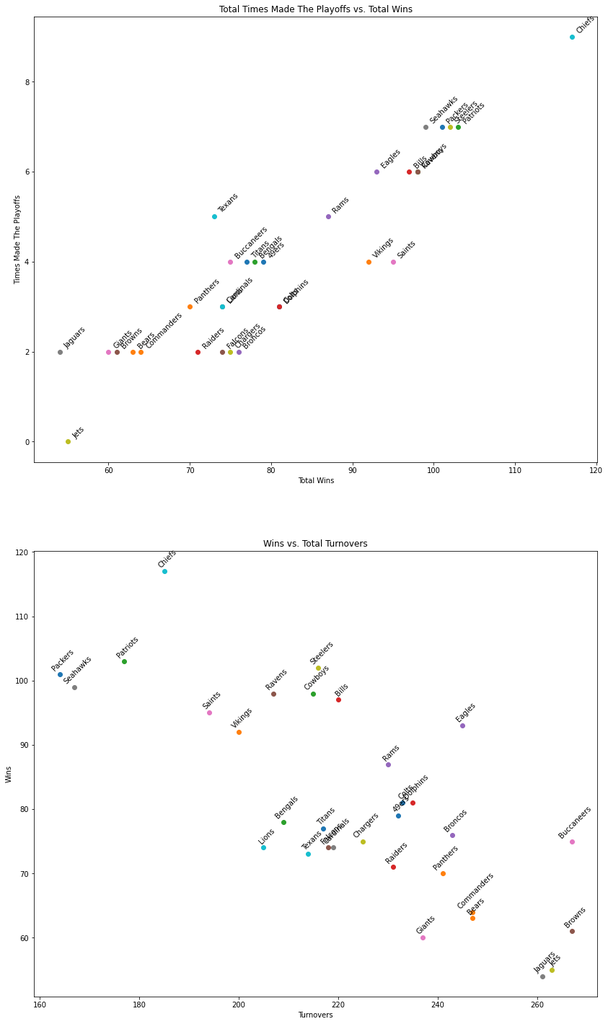

```python
fig, ax = plt.subplots(2, 1, figsize=(14, 25))

plt.figure(figsize = (14, 10))
for team, row in all_years.iterrows():
    ax[0].scatter(row['wins'], row['made_post_season'])
    ax[0].annotate(team, (row['wins'], row['made_post_season']), textcoords="offset points", xytext=(5,5), ha='left', rotation=45)

    ax[1].scatter(row['interceptions'] + row['fumbles'], row['wins'])
    ax[1].annotate(team, (row['interceptions'] + row['fumbles'], row['wins']), textcoords="offset points", xytext=(5,5), ha='center', rotation=45)

ax[0].set_xlabel('Total Wins')
ax[0].set_ylabel('Times Made The Playoffs')
ax[0].set_title('Total Times Made The Playoffs vs. Total Wins')

ax[1].set_xlabel('Turnovers')
ax[1].set_ylabel('Wins')
ax[1].set_title('Wins vs. Total Turnovers')

plt.show()
```

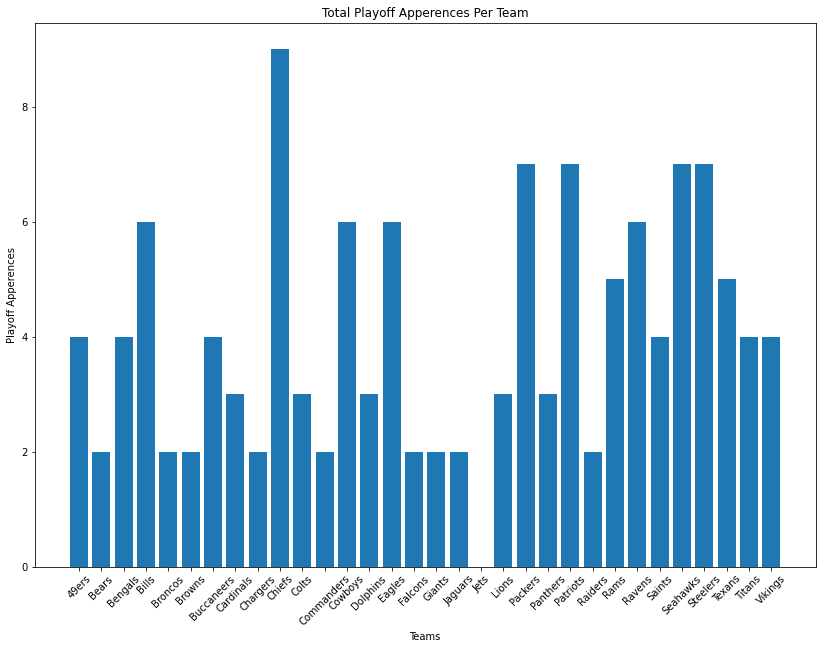

```python
plt.figure(figsize = (14, 10))

plt.bar(all_years.index, all_years['made_post_season'])

plt.xlabel('Teams')
plt.xticks(rotation=45)
plt.ylabel('Playoff Apperences')
plt.title('Total Playoff Apperences Per Team')
plt.show()
```

The last three plots use the team data for each year and look at how different stats affect the amount of games won by a team.

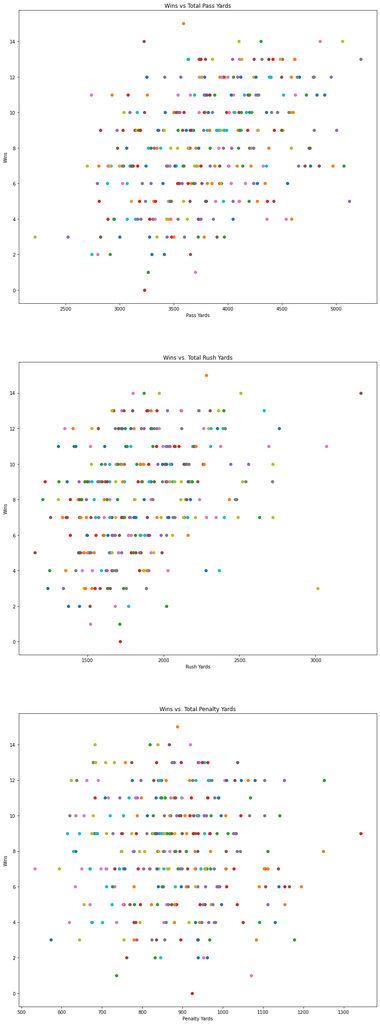

```python
fig, ax = plt.subplots(3, 1, figsize=(14, 40))
for team, row in team_year.iterrows():
    ax[0].scatter(row['pass_yards'], row['wins'])
    ax[1].scatter(row['rush_yards'], row['wins'])
    ax[2].scatter(row['pen_yards'], row['wins'])

ax[0].set_xlabel('Pass Yards')
ax[0].set_ylabel('Wins')
ax[0].set_title('Wins vs Total Pass Yards')

ax[1].set_xlabel('Rush Yards')
ax[1].set_ylabel('Wins')
ax[1].set_title('Wins vs. Total Rush Yards')

ax[2].set_xlabel('Penalty Yards')
ax[2].set_ylabel('Wins')
ax[2].set_title('Wins vs. Total Penalty Yards')
plt.show()
```

Analysis, Hypothesis, Testing, & Machine Learning

```python
data = team_year[['pass_yards', 'rush_yards', 'sacks_num', 'pen_yards', 'fumbles', 'interceptions', 'score', 'wins']]
target = team_year['made_post_season']
```

```python
train_data = data.iloc[:-32]
test_data = data.iloc[-32:]
train_target = target.iloc[:-32]
test_target = target.iloc[-32:]
```

Learn more about binary classification problems: https://www.datacamp.com/blog/classification-machine-learning

```python
def grad_descent_log_regression(X, y, num_iterations, learn_rate):
    m, n = X.shape
    theta = np.zeros(n)
    bias =  0

    # Looping through all iterations
    for i in range(num_iterations):

        # Hypothesis function
        z = np.dot(X, theta) + bias
        y_pred = 1/(1 + np.exp(-z))

        # Optimization
        dw = (1 / m) * np.dot(X.T, y_pred - y)
        db = (1 / m) * np.sum(y_pred - y)

        # Changing the values of the weights and biases
        theta -= learn_rate * dw
        bias -= learn_rate * db

    return theta, bias
```

Before we put our data into the model we must first normalize the data. This is due to each field having different ranges of values. Having a huge range of values can cause the model to have a heavier weight towards a certain field when it should not.

Also with this model, you have a learning rate and a number of iterations. The learning rate controls how much the weights can be changed each iteration. A small learning rate can cause your algorithm to not reach the minimum point. A large learning rate can cause your algorithm to diverge. The number of iterations is how many times the algorithm runs before finding the minimum point.

```python
# Normalizing the training data
values = train_data.values
train_mean = np.mean(values, axis = 0)
train_std = np.std(values, axis = 0)
norm_train_data = (values - train_mean) / train_std

train_target_values = train_target.values

# Setting number of iterations and learning rate
num_iterations = 10000
learn_rate = .1

# Using the function
theta, bias = grad_descent_log_regression(norm_train_data, train_target_values, num_iterations, learn_rate)

# Printing the weights for each column and bias
for name, weight in zip(train_data.columns, theta):
    print(f'{name}: {weight}')
print("Bias: ", bias)
```

```
pass_yards: 1.1394404211731364
rush_yards: 0.8460441150470683
sacks_num: 0.1705030246542741
pen_yards: -0.2711874166334538
fumbles: 0.005682794062058462
interceptions: -0.7638205827954652
score: -1.6398911240381822
wins: 7.028929101103152
Bias:  -2.308635861934404
```

Now that we have our model we want to test the model on the test data. Since we normalized the training data you must normalize the test data with the same mean and standard deviation. Then we can use the model to get the predicted values.

```python
# Standarizing the test data before finding predicted values
pred = (test_data.values - train_mean) / train_std

#Predicting the values and computing the mean squarred error
z = np.dot(pred,theta) + bias
prob_prediction = 1/ (1 + np.exp(-z))
prediction = np.where(prob_prediction >= .5, 1, 0)
```

Now we can see how our model performed.

Accuracy is what percentage of the test data was classified correctly and lassification report shows a summary of different metrics used in model preformance. Lastly, are the amount of true positive, true negative, false positive, and false negatives that the model predicted.

```python
# Accuracy
accuracy = accuracy_score(test_target.values, prediction)
print("Accuracy:", accuracy)

# Classification report
print("Classification Report: \n", classification_report(test_target.values, prediction))

tn, fp, fn, tp = confusion_matrix(test_target.values, prediction).ravel()

# Print values
print(f'True Positive: {tp}')
print(f'True Negative: {tn}')
print(f'False Positive: {fp}')
print(f'False Negative: {fn}')
```

```
Accuracy: 0.90625
Classification Report:
               precision    recall  f1-score   support

           0       0.94      0.89      0.91        18
           1       0.87      0.93      0.90        14

    accuracy                           0.91        32
   macro avg       0.90      0.91      0.91        32
weighted avg       0.91      0.91      0.91        32

True Positive: 13
True Negative: 16
False Positive: 2
False Negative: 1
```

Finally, we will plot the receiver operating characteristic curve. The curve plots the True Positive Rate vs the False Positive Rate. The higher the area under the curve is the better the model is at predicting the test data.

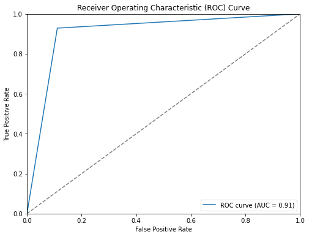

```python
# Assuming y_true contains the true labels and y_pred_proba contains the predicted probabilities for the positive class
fpr, tpr, thresholds = roc_curve(test_target.values, prediction)

# Compute the area under the ROC curve (AUC)
roc_auc = auc(fpr, tpr)

# Plot ROC curve
plt.figure(figsize=(8, 6))
plt.plot(fpr, tpr, label='ROC curve (AUC = %0.2f)' % roc_auc)
plt.plot([0, 1], [0, 1], color='gray', linestyle='--')
plt.xlim([0.0, 1.0])
plt.ylim([0.0, 1.0])
plt.xlabel('False Positive Rate')
plt.ylabel('True Positive Rate')
plt.title('Receiver Operating Characteristic (ROC) Curve')
plt.legend(loc='lower right')
plt.show()
```

Insight & Policy

This is the last part of the data science lifecycle. Here is where the model outcome is talked about and what can be done using the model.

We now have a working model that can use pass yards, rush yards, sack numbers, penalty yards, fumbles, interceptions, score, and wins to predict whether a team is likely to make it to the postseason. It is important to note that these are not the only variables that contribute to a team making the postseason. There are other variables that we dropped earlier, variables not included, and variables that do not fit traditionally into data. A team can have high offensive stats, but their defense can give up a lot of points which causes them to lose games. Also, there could be a tie of two teams that could make it to the postseason and the NFL tiebreaker rules will determine who makes it or not.

A model is great for making predictions, but it should not be looked at as the absolute future.